### **Tutorial**

VariantGuide compiles residue-level information for user-selected gene-encoded proteins. After uploading a variant list, users gain access to multiple layers of analysis, including 3D structural context, in silico predictions, allele frequencies, ACMG/AMP criteria, structural interpretation, variant reclassification or prioritization, and literature search results.

#### **Selecting Gene**

Choose the gene of interest by clicking the desired option in the selection box.

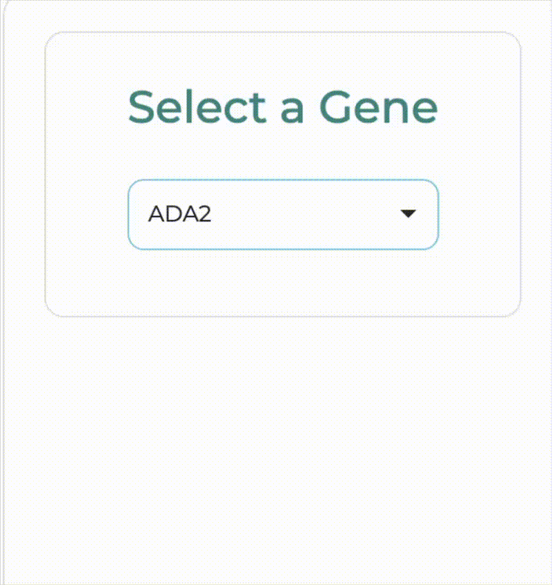

#### **Information and Statistics**

This tab presents general information about the protein encoded by the selected gene and provides direct access to UniProt using the protein ID.

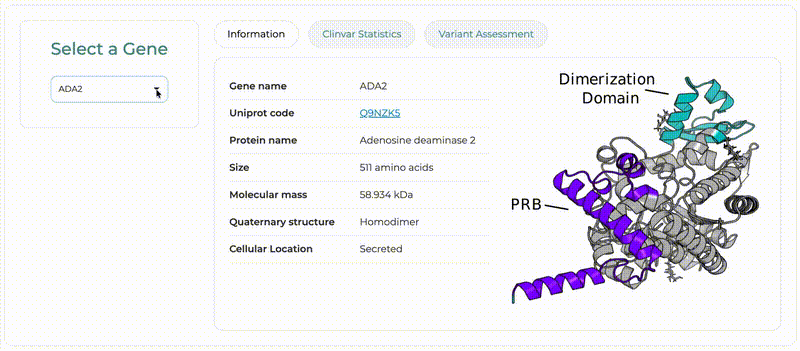

It also summarizes statistics such as the number of variants per protein domain, ClinVar classification distribution, conservation score profiles, and AI prediction errors per variant classification.

[figure not shown]

#### **Variant Upload**

Variants may be entered manually or uploaded as a .txt file via the Browse button. The required format for variant submission is shown in the examples provided below. To ensure proper processing, the list must not contain special characters (accents, symbols, spaces, or punctuation).

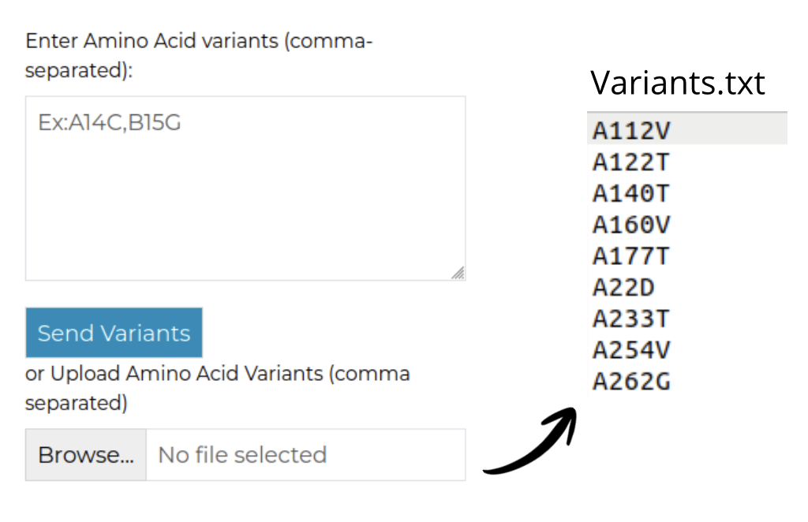

#### **3D Structure**

The 3D protein structure is available in the Variant Assessment window and is displayed in cartoon representation. For dimeric proteins, chain A is shown in light gray, while the uploaded variants are mapped onto chain B according to their respective positions. Variants are represented as colored dots based on their ACMG/AMP classification.

[figure not shown]

After entering your variants, the display is divided into two panels. The left panel shows the protein structure with your uploaded variants, while the right panel continues to display ClinVar variants for comparison.

[figure not shown]

The 3D Viewer is an interactive tool.

*Pan (drag): Click and hold the middle mouse button, then move the mouse.

*Zoom: Click and hold the right mouse button. Drag up to zoom out, or down to zoom in.

*Rotate: Click and hold the left mouse button, then drag to rotate the model.

#### **In Silico Predictions**

Upon variant upload, this tab provides AlphaMissense, REVEL, and MetaRNN prediction scores for each variant, along with their corresponding evidence strength for ACMG/AMP classification. Users may download this table as a csv file.

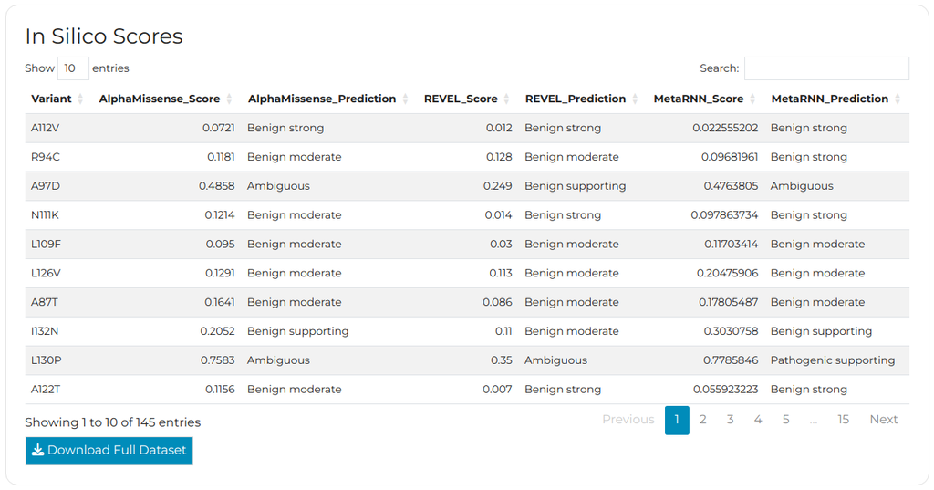

#### **Analysis of Variants**

Here, users will find allele frequencies, ClinVar classifications, ACMG/AMP criteria, structural interpretation output, VariantGuide reclassification and prioritization results, and, when available, literature references for each variant. A CSV export is also available.

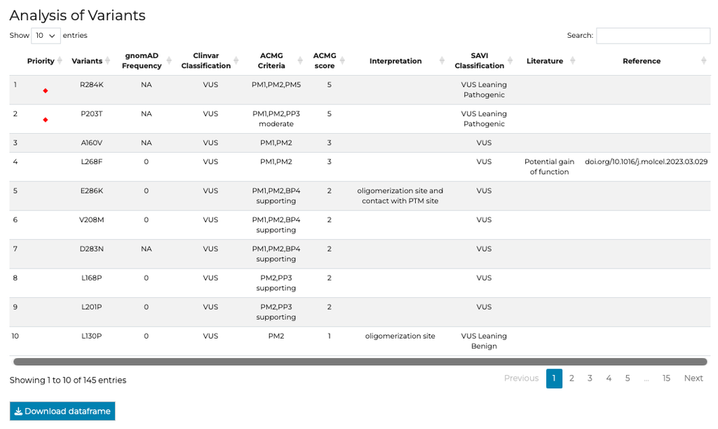

#### **Structural Information**

This section compiles structural biophysics features for each variant, including relative solvent accessibility, domain assignment, residue conservation, predicted stability changes, amino-acid type substitution effects, and a summarized structural interpretation. The full table can be downloaded as a CSV file.

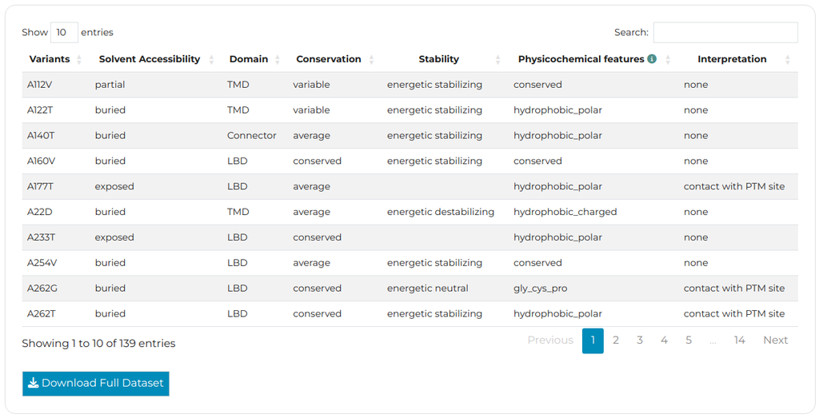